# 统计基础 1

DR

2025-02-23

## 1. 连续-分类变量分析

### 1.1 单样本T检验

单样本 T 检验用于比较样本均值与已知总体均值之间的差异。其前提条件是样本数据服从正态分布。 前置检验：正态性检验。 方法：可以使用 Shapiro - Wilk 检验来判断样本数据是否服从正态分布。在 R 语言中，可使用 shapiro.test() 函数.检验的 p 值大于显著性水平（通常为 0.05），则可以认为样本数据服从正态分布，满足单样本T检验的前提条件；否则，可能需要考虑使用非参数检验方法（如单样本 Wilcoxon 符号秩检验）

```r
# 假设我们有一个数据集 'heights'，其中有一列 'height' 表示身高数据，另一列 'group' 表示分组（例如，0表示control组，1表示treatment组）
# 我们要检验treatment组的平均身高是否显著不同于175cm

# 生成示例数据
set.seed(123)
heights <- data.frame(height = c(rnorm(30, 170, 10), rnorm(30, 180, 10)),
                      group = rep(c(0, 1), each = 30))

# 提取treatment组的数据
treatment_group <- heights[heights$group == 1, "height"]

# 单样本T检验
t.test(treatment_group, mu = 175)
```

```
##
##  One Sample t-test
##
## data:  treatment_group
## t = 4.4489, df = 29, p-value = 0.0001169
## alternative hypothesis: true mean is not equal to 175
## 95 percent confidence interval:
##  178.6650 184.9018
## sample estimates:
## mean of x
##  181.7834
```

### 1.2 独立样本T检验

**示例：**

```r
# 比较control组和treatment组之间的平均身高差异
control_group <- heights[heights$group == 0, "height"]
t.test(control_group, treatment_group)
```

```
##
##  Welch Two Sample t-test
##
## data:  control_group and treatment_group
## t = -5.2098, df = 56.559, p-value = 2.755e-06
## alternative hypothesis: true difference in means is not equal to 0
## 95 percent confidence interval:
##  -16.965426  -7.543416
## sample estimates:
## mean of x mean of y
##  169.5290  181.7834
```

### 1.3 配对样本 T 检验

配对样本 T 检验用于比较配对数据的均值差异，例如同一组对象在不同时间点的测量值。要求配对差值服从正态分布,计算配对数据的差值，然后对差值进行 Shapiro - Wilk 检验。。

```r
# 生成配对数据
set.seed(456)
before <- rnorm(20, 100, 10)
after <- before + rnorm(20, 5, 2)
paired_data <- data.frame(before = before, after = after)

# 配对样本T检验
t.test(paired_data$before, paired_data$after, paired = TRUE)
```

```
##
##  Paired t-test
##
## data:  paired_data$before and paired_data$after
## t = -10.447, df = 19, p-value = 2.591e-09
## alternative hypothesis: true mean difference is not equal to 0
## 95 percent confidence interval:
##  -5.424289 -3.613555
## sample estimates:
## mean difference
##       -4.518922
```

```r
# 假设我们有一个数据集 'data'，其中有一列 'score' 表示成绩，另一列 'class' 表示班级（1, 2, 3）
# 我们要比较不同班级之间的平均成绩差异

# 生成示例数据
set.seed(456)
data <- data.frame(score = c(rnorm(30, 80, 10), rnorm(30, 85, 10), rnorm(30, 90, 10)),
                   class = factor(rep(1:3, each = 30)))

# 进行ANOVA检验
anova_result <- aov(score ~ class, data = data)
summary(anova_result)
```

```
##             Df Sum Sq Mean Sq F value Pr(>F)
## class        2    707   353.5   3.383 0.0385 *
## Residuals   87   9093   104.5
## ---
## Signif. codes:  0 '***' 0.001 '**' 0.01 '*' 0.05 '.' 0.1 ' ' 1
```

1.5 非参数检验 - 单样本 Wilcoxon 符号秩检验 当数据不满足正态分布时，可以使用单样本 Wilcoxon 符号秩检验来替代单样本 T 检验，用于检验样本中位数是否等于某个已知值。

```r
# 生成非正态分布数据
set.seed(789)
non_normal_data <- rgamma(30, shape = 2, rate = 1)

# 单样本Wilcoxon符号秩检验
wilcox.test(non_normal_data, mu = 2)
```

```
##
##  Wilcoxon signed rank exact test
##
## data:  non_normal_data
## V = 80, p-value = 0.001131
## alternative hypothesis: true location is not equal to 2
```

1.6 非参数检验 - Mann - Whitney U 检验 当两个独立样本不满足正态分布或方差齐性时，可以使用 Mann - Whitney U 检验来替代独立样本 T 检验，用于比较两个独立样本的分布位置。

```r
# 生成非正态分布的两组数据
set.seed(1011)
group1 <- rgamma(20, shape = 2, rate = 1)
group2 <- rgamma(20, shape = 3, rate = 1)

# Mann - Whitney U检验
wilcox.test(group1, group2)
```

```
##
##  Wilcoxon rank sum exact test
##
## data:  group1 and group2
## W = 76, p-value = 0.0005305
## alternative hypothesis: true location shift is not equal to 0
```

1.7 非参数检验 - Kruskal - Wallis 检验 当多个独立样本不满足正态分布或方差齐性时，可以使用 Kruskal - Wallis 检验来替代 ANOVA，用于比较多个独立样本的分布位置。

```r
# 生成非正态分布的多组数据
set.seed(1213)
group_a <- rgamma(20, shape = 2, rate = 1)
group_b <- rgamma(20, shape = 3, rate = 1)
group_c <- rgamma(20, shape = 4, rate = 1)
non_normal_multi_data <- data.frame(value = c(group_a, group_b, group_c),
                                    group = factor(rep(c("A", "B", "C"), each = 20)))

# Kruskal - Wallis检验
kruskal.test(value ~ group, data = non_normal_multi_data)
```

```
##
##  Kruskal-Wallis rank sum test
##
## data:  value by group
## Kruskal-Wallis chi-squared = 15.114, df = 2, p-value = 0.0005223
```

## 2. 连续-连续变量分析

### 2.1 相关分析

相关分析用于确定两个连续变量之间的线性关系。常用的相关系数有皮尔逊相关系数和斯皮尔曼相关系数。皮尔逊相关系数要求两个变量都服从正态分布，而斯皮尔曼相关系数是基于数据的秩次，不要求数据服从正态分布。 皮尔逊相关系数：需要进行正态性检验，判断两个变量是否都服从正态分布。方法同前文单样本 T 检验中的正态性检验，分别对两个变量进行 Shapiro - Wilk 检验。若不满足正态分布，应使用斯皮尔曼相关系数。 斯皮尔曼相关系数：不需要对数据进行正态性检验，因为它是基于数据的秩次进行计算的。

**示例：**

```r
# 假设我们有两个连续变量 'height' 和 'weight'，我们想要知道它们之间的相关性

# 生成示例数据
set.seed(789)
heights_weights <- data.frame(height = rnorm(50, 170, 10),
                              weight = rnorm(50, 70, 15))

# 计算皮尔逊相关系数
correlation_result <- cor.test(heights_weights$height, heights_weights$weight, method = "pearson")
correlation_result
```

```
##
##  Pearson's product-moment correlation
##
## data:  heights_weights$height and heights_weights$weight
## t = 0.023476, df = 48, p-value = 0.9814
## alternative hypothesis: true correlation is not equal to 0
## 95 percent confidence interval:
##  -0.2752189  0.2814706
## sample estimates:
##         cor
## 0.003388401
```

### 2.2 线性回归分析

线性回归分析用于建立两个连续变量之间的线性关系模型，通过一个变量来预测另一个变量。 前置检验：正态性检验、方差齐性检验（残差的方差齐性）和独立性检验（残差的独立性）。 正态性检验：对回归模型的残差进行 Shapiro - Wilk 检验。在R语言中，可先建立线性回归模型，然后提取残差进行检验。方差齐性检验：可使用 car 包中的 ncvTest() 函数对残差进行方差齐性检验。独立性检验：可通过绘制残差与观测值顺序的图来初步判断残差是否独立，也可使用 Durbin - Watson 检验来检验残差的自相关性。在 R 语言中，可使用 car 包中的 durbinWatsonTest() 函数。 library(car) durbinWatsonTest(model) **示例：**

```r
# 建立身高和体重的线性回归模型
model <- lm(weight ~ height, data = heights_weights)
summary(model)
```

```
##
## Call:
## lm(formula = weight ~ height, data = heights_weights)
##
## Residuals:
##     Min      1Q  Median      3Q     Max
## -40.393 -11.302   1.239  10.875  34.230
##
## Coefficients:
##              Estimate Std. Error t value Pr(>|t|)
## (Intercept) 70.061527  40.758312   1.719   0.0921 .
## height       0.005668   0.241462   0.023   0.9814
## ---
## Signif. codes:  0 '***' 0.001 '**' 0.01 '*' 0.05 '.' 0.1 ' ' 1
##
## Residual standard error: 15.57 on 48 degrees of freedom
## Multiple R-squared:  1.148e-05,  Adjusted R-squared:  -0.02082
## F-statistic: 0.0005511 on 1 and 48 DF,  p-value: 0.9814
```

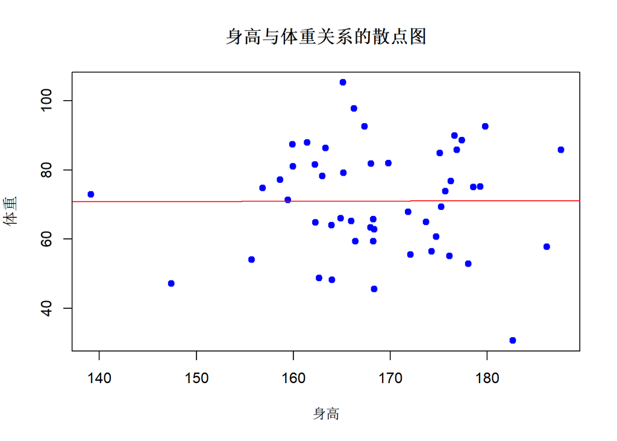

```r
# 绘制散点图并添加回归直线
plot(heights_weights$height, heights_weights$weight, main = "身高与体重关系的散点图",
     xlab = "身高", ylab = "体重", pch = 19, col = "blue")
abline(model, col = "red")
```

## 3. 分类-分类变量分析

### 3.1 卡方检验

卡方检验用于检验分类变量之间的独立性。当列联表中单元格的期望频数小于 5 时，卡方检验的结果可能不准确，此时可以使用 Fisher 精确检验。

**示例：**

```r
# 假设我们有两个分类变量 'smoker'（是否吸烟）和 'disease'（是否患病），我们想要知道它们是否相互独立

# 生成示例数据
set.seed(101112)
survey_data <- data.frame(smoker = factor(sample(c("yes", "no"), 50, replace = TRUE)),
                          disease = factor(sample(c("yes", "no"), 50, replace = TRUE)))

# 创建列联表
contingency_table <- table(survey_data$smoker, survey_data$disease)

# 进行卡方检验
chi_square_result <- chisq.test(contingency_table)
chi_square_result
```

```
##
##  Pearson's Chi-squared test with Yates' continuity correction
##
## data:  contingency_table
## X-squared = 0, df = 1, p-value = 1
```

```r
# 进行Fisher精确检验
fisher_result <- fisher.test(contingency_table)
fisher_result
```

```
##
##  Fisher's Exact Test for Count Data
##
## data:  contingency_table
## p-value = 1
## alternative hypothesis: true odds ratio is not equal to 1
## 95 percent confidence interval:
##  0.297679 3.883990
## sample estimates:
## odds ratio
##    1.06799
```

## 4. 作图

### 4.1 ANOVA结果作图

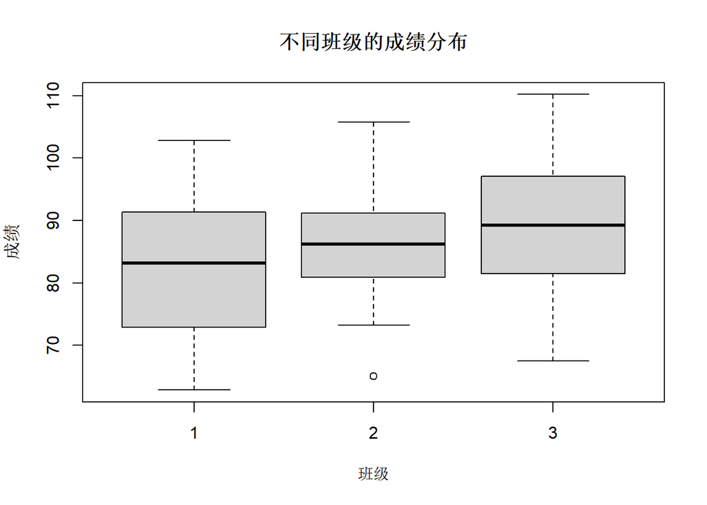

```r
# 使用boxplot画出不同班级之间的成绩分布
boxplot(score ~ class, data = data, main = "不同班级的成绩分布", xlab = "班级", ylab = "成绩")
```

### 4.2 相关分析作图

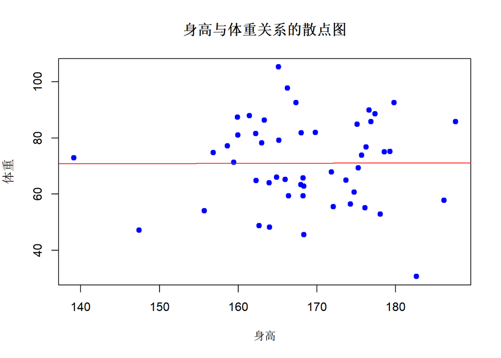

```r
# 使用scatterplot来绘制身高与体重之间的关系
plot(heights_weights$height, heights_weights$weight, main = "身高与体重关系的散点图",
     xlab = "身高", ylab = "体重", pch = 19, col = "blue")
abline(lm(heights_weights$weight ~ heights_weights$height), col = "red") # 添加拟合线
```

### 4.3 卡方检验结果作图

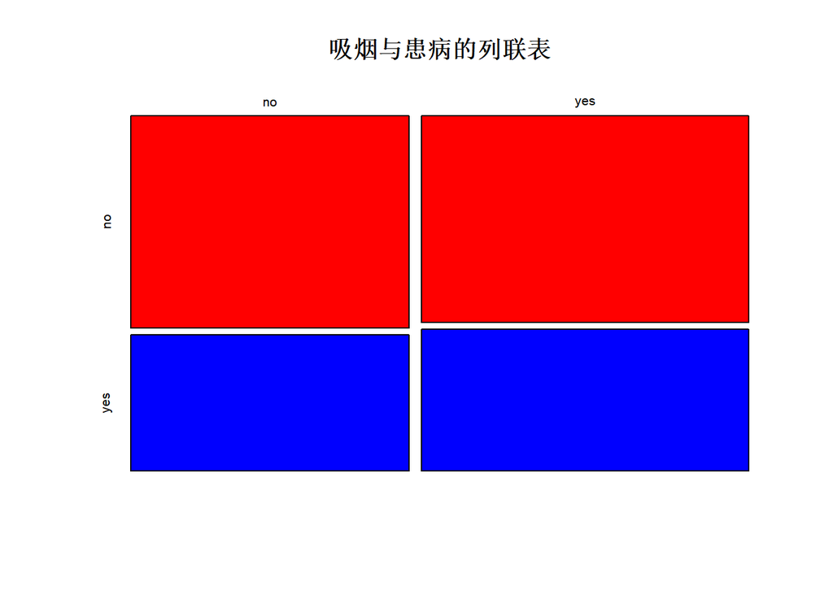

```r
# 使用mosaicplot绘制列联表
mosaicplot(contingency_table, main = "吸烟与患病的列联表", col = c("red", "blue"))
```

## 5 作业

从 mtcars 数据集中选择两个连续变量进行相关分析，解释分析结果。 使用 mtcars 数据集中的 mpg 和 cyl 进行单因素 ANOVA 分析，解释分析结果，并绘制 boxplot。 创建一个包含 50 个样本的数据集，每个样本有两个分类变量（例如，是否喜欢冰淇淋和是否喜欢甜食），并进行卡方检验，解释分析结果。 从 mtcars 数据集中选择两个连续变量，判断数据是否服从正态分布。若不服从，使用合适的非参数方法进行分析。 从 mtcars 数据集中选择一个连续变量和一个分类变量，判断连续变量是否满足正态分布和方差齐性。若不满足，使用合适的非参数方法进行分析。